# ELS Stress Interview Scoring

Lucy King

```r
#Libraries
library(tidyverse)
library(haven)
library(modelr)
#Parameters
els_t1_file <-
  "~/Desktop/ELS/stress_data/data/Best_ELS T1 Integrated Stress Interview_Panel Ratings_Copy 1._20180711.sav"
els_t2_file <-
  "~/Desktop/ELS/stress_data/data/ELS T2 Integrated Stress Interview_Panel Ratings_Copy 1 USE_1._20180711.sav"
lca_class_t1_file <-
  "~/Desktop/ELS/stress_data/data/els_t1_lca_class.csv"
## Functions
spread_els_data <- function(data, rating) {

  rating <- enquo(rating)

  data %>%
  select(
    ELS_ID,
    event_domain_re,
    !! rating
  ) %>%
  group_by(ELS_ID, event_domain_re) %>%
  filter(
    !! rating == max(
      !! rating, na.rm = TRUE
    )
  ) %>%
  distinct(
    event_domain_re,
    !! rating
  ) %>%
  gather(key1, value, !! rating) %>%
  unite(key2, event_domain_re, key1, sep = "_") %>%
  spread(key2, value) %>%
  ungroup()

}
```

# Read in T1 data

```r
els_t1 <-
  read_sav(els_t1_file) %>%
  mutate_at(
    vars(Perpetrator:Panel_Independent_Decision),
    funs(as.double)
  ) %>%
  mutate(
    ELS_ID = as.integer(ELS_ID),
    Event_Domain = as.integer(Event_Domain),
    Event_Domain_Notes = as.character(Event_Domain_Notes),
    panel_objective_decision_re = recode(
      Panel_Objective_Decision,
      "1" = 0,
      "1.5" = .5,
      "2" = 1,
      "2.5" = 1.5,
      "3" = 2,
      "3.5" = 2.5,
      "4" = 3,
      "4.5" = 3.5,
      "5" = 4
    ),
    panel_objective_decision_re = if_else(
      Event_Domain == 0,
      0, panel_objective_decision_re
    ),
    child_subjective_rating = if_else(
      Event_Domain == 0,
      0, Child_Subjective_Rating
    ),
    event_domain_re = recode(
      Event_Domain,
      "1" = "exp_acc",
      "2" = "wit_acc",
      "3" = "disaster",
      "4" = "exp_ill",
      "5" = "wit_ill",
      "6" = "death",
      "7" = "sep_wt", #separation from parents due to work/travel
      "8" = "moved",
      "9" = "divorce",
      "10" = "sep_rfd", #separation from parents due to rehab, foster care, detention
      "11" = "mental_ill",
      "12" = "suicide",
      "13" = "phys_ab",
      "14" = "thrt_phys_ab",
      "15" = "bully",
      "16" = "kidnap",
      "17" = "animal",
      "18" = "parent_arg",
      "19" = "thrt_domvio",
      "20" = "dom_viol",
      "21" = "legal_prob",
      "22" = "comm_arg",
      "23" = "comm_phys",
      "24" = "war_terr",
      "25" = "sex_ab",
      "26" = "wit_sexab",
      "27" = "emo_ab",
      "28" = "neglect",
      "29" = "finance",
      "30" = "other",
      "31" = "comm_inst",
      "32" = "mug_rob",
      .default = "nothing_reported"
    )
  ) %>%
  group_by(ELS_ID) %>%
  mutate(
    num_report_t1 = if_else(
      Event_Domain != 0,
      n(), as.integer(0)
    )
  ) %>%
  ungroup()
# replace user-defined missing values with NA
els_t1[els_t1 == 777] <- NA
els_t1[els_t1 == 888] <- NA
els_t1[els_t1 == 999] <- NA
```

# Read in T2 data

```r
els_t2 <-
  read_sav(els_t2_file) %>%
  mutate_at(
    vars(Perpetrator:Panel_Independent_Decision),
    funs(as.double)
  ) %>%
  mutate(
    ELS_ID = as.integer(ELS_ID), #coercing to integer to remove .2 and .5 indicators -- do not need them
    Event_Domain = as.integer(Event_Domain),
    Event_Domain_Notes = as.character(Event_Domain_Notes),
    panel_objective_decision_re = recode(
      Panel_Objective_Decision,
      "1" = 0,
      "1.5" = .5,
      "2" = 1,
      "2.5" = 1.5,
      "3" = 2,
      "3.5" = 2.5,
      "4" = 3,
      "4.5" = 3.5,
      "5" = 4
    ),
    panel_objective_decision_re = if_else(
      Event_Domain == 0,
      0, panel_objective_decision_re
    ),
    child_subjective_rating = if_else(
      Event_Domain == 0,
      0, Child_Subjective_Rating
    ),
    event_domain_re = recode(
      Event_Domain,
      "1" = "exp_acc",
      "2" = "wit_acc",
      "3" = "disaster",
      "4" = "exp_ill",
      "5" = "wit_ill",
      "6" = "death",
      "7" = "sep_wt", #separation from parents due to work/travel
      "8" = "moved",
      "9" = "divorce",
      "10" = "sep_rfd", #separation from parents due to rehab, foster care, detention
      "11" = "mental_ill",
      "12" = "suicide",
      "13" = "phys_ab",
      "14" = "thrt_phys_ab",
      "15" = "bully",
      "16" = "kidnap",
      "17" = "animal",
      "18" = "parent_arg",
      "19" = "thrt_domvio",
      "20" = "dom_viol",
      "21" = "legal_prob",
      "22" = "comm_arg",
      "23" = "comm_phys",
      "24" = "war_terr",
      "25" = "sex_ab",
      "26" = "wit_sexab",
      "27" = "emo_ab",
      "28" = "neglect",
      "29" = "finance",
      "30" = "other",
      "31" = "comm_inst",
      "32" = "mug_rob",
      .default = "nothing_reported"
    )
  ) %>%
  group_by(ELS_ID) %>%
  mutate(
    num_report_t2 = if_else(
      Event_Domain != 0,
      n(), as.integer(0)
    )
  ) %>%
  ungroup()
# replace user-defined missing values with NA
els_t2[els_t2 == 777] <- NA
els_t2[els_t2 == 888] <- NA
els_t2[els_t2 == 999] <- NA
```

# Calculate severity scores: Lifetime to T1

```r
els_t1_obj <-
  spread_els_data(els_t1, panel_objective_decision_re)
els_t1_subj <-
  spread_els_data(els_t1, child_subjective_rating)
```

[output not shown]

```r
sev_rating_vars_T1 <-
  els_t1_obj %>%
  select(
    ends_with("panel_objective_decision_re")
  ) %>%
  names()
sub_sev_rating_vars_T1 <-
  els_t1_subj %>%
  select(
    ends_with("child_subjective_rating")
  ) %>%
  names()
```

```r
els_t1_obj <-
  els_t1_obj %>%
  mutate(
    sumsev_type_t1 = pmap_dbl(
      select(., sev_rating_vars_T1),
      function(...) sum(c(...), na.rm = TRUE)
    ),
    z_sumsev_type_t1 = scale(sumsev_type_t1, scale = TRUE),
    maxsev_t1 = pmap_dbl(
      select(., sev_rating_vars_T1),
      function(...) max(c(...), na.rm = TRUE)
    ),
    num_type_t1 = pmap_int(
      select(., sev_rating_vars_T1),
      function(...) sum(c(...) > 0, na.rm = TRUE)
    )
  ) %>%
  left_join(els_t1 %>% select(ELS_ID, num_report_t1) %>% unique(), by = "ELS_ID")
```

```r
els_t1_subj <-
  els_t1_subj %>%
  mutate(
    sumsub_type_t1 = pmap_dbl(
      select(., sub_sev_rating_vars_T1),
      function(...) sum(c(...), na.rm = TRUE)
    ),
    z_sumsub_type_t1  = scale(sumsub_type_t1, scale = TRUE),
    maxsub_t1 = pmap_dbl(
      select(., sub_sev_rating_vars_T1),
      function(...) max(c(...), na.rm = TRUE)
    )
  )
```

```r
els_t1_wf <-
  els_t1_obj %>%
  left_join(els_t1_subj, by = "ELS_ID")
```

### T1 Threat

The below generates a measure of threat using the definition provided by Sheridan & McLaughlin (2014):

In the ELS study, the semi-structered “ELS Interview” is a modified version of the TESI-C. The majority of the items on this interview could be viewed as “threat.” However, some items more clearly align with the definition of Sheridan & McLaughlin (e.g., domestic violence) while others are less clear (e.g., witnessing an accident) because of variation in the severity of experiences reported in certain categories. Therefore, we decided to be conservative and include items that are clearly threatening because they involve interpersonal harmful input to either child, someone close to the child, or the child’s community.

```r
threat_vars_t1 <-
  els_t1_wf %>%
  select(
    comm_arg_panel_objective_decision_re,
    comm_inst_panel_objective_decision_re,
    comm_phys_panel_objective_decision_re,
    bully_panel_objective_decision_re,
    thrt_domvio_panel_objective_decision_re,
    thrt_phys_ab_panel_objective_decision_re,
    kidnap_panel_objective_decision_re,
    parent_arg_panel_objective_decision_re,
    dom_viol_panel_objective_decision_re,
    war_terr_panel_objective_decision_re,
    emo_ab_panel_objective_decision_re,
    phys_ab_panel_objective_decision_re,
    sex_ab_panel_objective_decision_re,
    wit_sexab_panel_objective_decision_re,
    mug_rob_panel_objective_decision_re
  ) %>%
  names()
```

```r
els_t1_wf <-
  els_t1_wf %>%
  mutate(
    sumsev_threat_t1 = pmap_dbl(
      select(., threat_vars_t1),
      function(...) sum(c(...), na.rm = TRUE)
    )
  )
```

# Calculate severity scores T2: Events occuring between T1 and T2

```r
els_t2_obj <-
  spread_els_data(els_t2, panel_objective_decision_re)
```

```
no non-missing arguments to max; returning -Infno non-missing arguments to max; returning -Infno non-missing arguments to max; returning -Infno non-missing arguments to max; returning -Infno non-missing arguments to max; returning -Inf
```

```r
els_t2_subj <-
  spread_els_data(els_t2, child_subjective_rating)
```

[output not shown]

```r
sev_rating_vars_T2 <-
  els_t2_obj %>%
  select(
    ends_with("panel_objective_decision_re")
  ) %>%
  names()
sub_sev_rating_vars_T2 <-
  els_t2_subj %>%
  select(
    ends_with("child_subjective_rating")
  ) %>%
  names()
```

```r
els_t2_obj <-
  els_t2_obj %>%
  mutate(
    sumsev_type_t2 = pmap_dbl(
      select(., sev_rating_vars_T2),
      function(...) sum(c(...), na.rm = TRUE)
    ),
    z_sumsev_type_t2 = scale(sumsev_type_t2, scale = TRUE),
    maxsev_t2 = pmap_dbl(
      select(., sev_rating_vars_T2),
      function(...) max(c(...), na.rm = TRUE)
    ),
    num_type_t2 = pmap_int(
      select(., sev_rating_vars_T2),
      function(...) sum((c(...) > 0), na.rm = TRUE)
    )
  ) %>%
  left_join(els_t2 %>% select(ELS_ID, num_report_t2) %>% unique(), by = "ELS_ID")
```

```r
els_t2_subj <-
  els_t2_subj %>%
  mutate(
    sumsub_type_t2 = pmap_dbl(
      select(., sub_sev_rating_vars_T2),
      function(...) sum(c(...), na.rm = TRUE)
    ),
    z_sumsub_type_t2  = scale(sumsub_type_t2, scale = TRUE),
    maxsub_t2 = pmap_dbl(
      select(., sub_sev_rating_vars_T2),
      function(...) max(c(...), na.rm = TRUE)
    )
  )
```

```r
els_t2_wf <-
  els_t2_obj %>%
  left_join(els_t2_subj, by = "ELS_ID")
```

### T2 Threat

```r
threat_vars_t2 <-
  els_t1_wf %>%
  select(
    comm_arg_panel_objective_decision_re,
    comm_inst_panel_objective_decision_re,
    comm_phys_panel_objective_decision_re,
    bully_panel_objective_decision_re,
    thrt_domvio_panel_objective_decision_re,
    thrt_phys_ab_panel_objective_decision_re,
    parent_arg_panel_objective_decision_re,
    dom_viol_panel_objective_decision_re,
    war_terr_panel_objective_decision_re,
    emo_ab_panel_objective_decision_re,
    mug_rob_panel_objective_decision_re
  ) %>%
  names()
```

```r
els_t2_wf <-
  els_t2_wf %>%
  mutate(
    sumsev_threat_t2 = pmap_dbl(
      select(., threat_vars_t2),
      function(...) sum(c(...), na.rm = TRUE)
    )
  )
```

# Calculate severity scores T1 and T2: Lifetime up to T2

Important: If someone did not come in for T2 their “t1t2” scores are simply their t1 scores.

```r
els_t1t2_obj <-
  els_t1_obj %>%
  select(-ends_with("t1")) %>%
  bind_rows(
    els_t2_obj %>%
      select(-ends_with("t2"))
  ) %>%
  gather(type, rating, -ELS_ID) %>%
  mutate_at(
    vars(rating),
    as.double
  ) %>%
  mutate_at(
    vars(rating),
    funs(
      if_else(
        is.na(.),
        0, .
      )
    )
  ) %>%
  group_by(ELS_ID, type) %>%
  filter(
    rating == max(rating, na.rm = TRUE)
  ) %>%
  distinct(type, rating) %>%
  spread(type, rating) %>%
  ungroup()
```

```r
els_t1t2_subj <-
  els_t1_subj %>%
  select(-ends_with("t1")) %>%
  bind_rows(
    els_t2_subj %>%
      select(-ends_with("t2"))
  ) %>%
  gather(type, rating, -ELS_ID) %>%
  mutate_at(
    vars(rating),
    as.double
  ) %>%
  mutate_at(
    vars(rating),
    funs(
      if_else(
        is.na(.),
        0, .
      )
    )
  ) %>%
  group_by(ELS_ID, type) %>%
  filter(
    rating == max(rating, na.rm = TRUE)
  ) %>%
  distinct(type, rating) %>%
  spread(type, rating) %>%
  ungroup()
```

```r
sev_rating_vars_t1t2 <-
  els_t1t2_obj %>%
  select(
    ends_with("panel_objective_decision_re")
  ) %>%
  names()
sub_sev_rating_vars_t1t2 <-
  els_t1t2_subj %>%
  select(
    ends_with("child_subjective_rating")
  ) %>%
  names()
```

```r
els_t1t2_obj <-
  els_t1t2_obj %>%
  mutate(
    sumsev_type_t1t2 = pmap_dbl(
      select(., sev_rating_vars_t1t2),
      function(...) sum(c(...), na.rm = TRUE)
    ),
    z_sumsev_type_t1t2 = scale(sumsev_type_t1t2, scale = TRUE),
    maxsev_t1t2 = pmap_dbl(
      select(., sev_rating_vars_t1t2),
      function(...) max(c(...), na.rm = TRUE)
    ),
    num_type_t1t2 = pmap_int(
      select(., sev_rating_vars_t1t2),
      function(...) sum(c(...) > 0, na.rm = TRUE)
    )
  ) %>%
  left_join(els_t1 %>% select(ELS_ID, num_report_t1) %>% unique(), by = "ELS_ID") %>%
  left_join(els_t2 %>% select(ELS_ID, num_report_t2) %>% unique(), by = "ELS_ID") %>%
  group_by(ELS_ID) %>%
  mutate(
    num_report_t1t2 = sum(
      c(num_report_t1, num_report_t2),
      na.rm = TRUE
    )
  ) %>%
  ungroup()
```

```r
els_t1t2_subj <-
  els_t1t2_subj %>%
  mutate(
    sumsub_type_t1t2 = pmap_dbl(
      select(., sub_sev_rating_vars_t1t2),
      function(...) sum(c(...), na.rm = TRUE)
    ),
    z_sumsub_type_t1t2  = scale(sumsub_type_t1t2, scale = TRUE),
    maxsub_t1t2 = pmap_dbl(
      select(., sub_sev_rating_vars_t1t2),
      function(...) max(c(...), na.rm = TRUE)
    )
  ) %>%
  ungroup()
```

```r
els_t1t2 <-
  els_t1t2_obj %>%
  left_join(els_t1t2_subj, by = "ELS_ID") %>%
  distinct(ELS_ID, sumsev_type_t1t2, .keep_all = TRUE)
```

### T1 and T2 Threat

```r
els_t1t2 <-
  els_t1t2 %>%
  mutate(
    sumsev_threat_t1t2 = pmap_dbl(
      select(., threat_vars_t1),
      function(...) sum(c(...), na.rm = TRUE)
    )
  )
```

# Stress by development stage

## Calculate sumsev_type T1: Onset age < 6

Do not use if you want to use actual age of each event in your analysis. `distinct()` selects unique rows after filter to be events occuring with onset up to age 6.

```r
els_t1_early_6 <-
  els_t1 %>%
  select(
    ELS_ID,
    event_domain_re,
    age_onset = Age_onset,
    panel_objective_decision_re
  ) %>%
  group_by(ELS_ID, event_domain_re) %>%
  filter(
    panel_objective_decision_re == max(
      panel_objective_decision_re, na.rm = TRUE
    ),
    age_onset < 6
  ) %>%
  distinct(event_domain_re, panel_objective_decision_re) %>%
  gather(key1, value, panel_objective_decision_re) %>%
  unite(key2, event_domain_re, key1, sep = "_") %>%
  spread(key2, value) %>%
  ungroup()
```

```r
sev_rating_vars_6 <-
  els_t1_early_6 %>%
  select(
    ends_with("panel_objective_decision_re")
  ) %>%
  names()
```

```r
els_t1_early_6 <-
  els_t1_early_6 %>%
  mutate(
    sumsev_type_6 = pmap_dbl(
      select(., sev_rating_vars_6),
      function(...) sum(c(...), na.rm = TRUE)
    ),
    maxsev_6 = pmap_dbl(
      select(., sev_rating_vars_6),
      function(...) max(c(...), na.rm = TRUE)
    ),
    num_type_6 = pmap_dbl(
      select(., sev_rating_vars_6),
      function(...) sum((c(...) > 0), na.rm = TRUE)
    )
  )
```

## Calculate sumsev_type T1: Onset age >= 6

```r
els_t1_early_7 <-
  els_t1 %>%
  select(
    ELS_ID,
    event_domain_re,
    age_onset = Age_onset,
    panel_objective_decision_re
  ) %>%
  group_by(ELS_ID, event_domain_re) %>%
  filter(
    panel_objective_decision_re == max(
      panel_objective_decision_re, na.rm = TRUE
    ),
    age_onset >= 6
  ) %>%
  distinct(event_domain_re, panel_objective_decision_re) %>%
  gather(key1, value, panel_objective_decision_re) %>%
  unite(key2, event_domain_re, key1, sep = "_") %>%
  spread(key2, value) %>%
  ungroup()
```

```r
sev_rating_vars_7 <-
  els_t1_early_7 %>%
  select(
    ends_with("panel_objective_decision_re")
  ) %>%
  names()
```

```r
els_t1_early_7 <-
  els_t1_early_7 %>%
  mutate(
    sumsev_type_7 = pmap_dbl(
      select(., sev_rating_vars_7),
      function(...) sum(c(...), na.rm = TRUE)
    ),
    maxsev_7 = pmap_dbl(
      select(., sev_rating_vars_7),
      function(...) max(c(...), na.rm = TRUE)
    ),
    num_type_7 = pmap_int(
      select(., sev_rating_vars_7),
      function(...) sum((c(...) > 0), na.rm = TRUE)
    )
  )
```

## Calculate sumsev_type T1 and T2: Onset age >= 6 (i.e., events reported as occuring >=6 at either T1 or T2)

Not filterting T2 data set to >= age 6 because all events in this dataset occured within T1 to T2 interval.

```r
els_t1t2_7 <-
  els_t1 %>%
  select(
    ELS_ID,
    event_domain_re,
    age_onset = Age_onset,
    panel_objective_decision_re
  ) %>%
  group_by(ELS_ID, event_domain_re) %>%
  filter(
    panel_objective_decision_re == max(
      panel_objective_decision_re, na.rm = TRUE
    ),
    age_onset >= 6
  ) %>%
  distinct(event_domain_re, panel_objective_decision_re) %>%
  gather(key1, value, panel_objective_decision_re) %>%
  mutate(
    timepoint = "T1"
  ) %>%
  bind_rows(
    els_t2 %>%
      select(
        ELS_ID,
        event_domain_re,
        age_onset = Age_onset,
        age_offset = Age_offset,
        panel_objective_decision_re
      ) %>%
      group_by(ELS_ID, event_domain_re) %>%
      filter(
        panel_objective_decision_re == max(
          panel_objective_decision_re, na.rm = TRUE
        )
      ) %>%
      distinct(event_domain_re, panel_objective_decision_re) %>%
      gather(key1, value, panel_objective_decision_re) %>%
      mutate(timepoint = "T2")
  ) %>%
  unite(key2, event_domain_re, key1, sep = "_") %>%
  unite(key3, timepoint, key2, sep = "_") %>%
  spread(key3, value) %>%
  ungroup()
```

```
no non-missing arguments to max; returning -Infno non-missing arguments to max; returning -Infno non-missing arguments to max; returning -Infno non-missing arguments to max; returning -Infno non-missing arguments to max; returning -Inf
```

```r
sev_rating_vars_t1t2_7 <-
  els_t1t2_7 %>%
  select(
    ends_with("panel_objective_decision_re")
  ) %>%
  names()
```

```r
els_t1t2_7 <-
  els_t1t2_7 %>%
  mutate(
    sumsev_type_7_t1t2 = pmap_dbl(
      select(., sev_rating_vars_t1t2_7),
      function(...) sum(c(...), na.rm = TRUE)
    ),
    maxsev_7_t1t2 = pmap_dbl(
      select(., sev_rating_vars_t1t2_7),
      function(...) max(c(...), na.rm = TRUE)
    ),
    num_type_7_t1t2 = pmap_int(
      select(., sev_rating_vars_t1t2_7),
      function(...) sum((c(...) > 0), na.rm = TRUE)
    )
  )
```

# Stress sensitivity

## Calculate stress sensitivity T1: Lifetime to T1

```r
sens_t1_mod <- lm(z_sumsub_type_t1 ~ z_sumsev_type_t1, data = els_t1_wf)
els_t1_wf <-
  els_t1_wf %>%
  add_residuals(sens_t1_mod, var = "sss_t1")
```

## Calculate stress sensitivity T2: Events occuring between T1 and T2

```r
sens_t2_mod <- lm(z_sumsub_type_t2 ~ z_sumsev_type_t2, data = els_t2_wf)
els_t2_wf <-
  els_t2_wf %>%
  add_residuals(sens_t2_mod, var = "sss_t2")
```

## Calculate stress sensitivity T1 and T2: Lifetime up to T2

```r
sens_t1t2_mod <- lm(z_sumsub_type_t1t2 ~ z_sumsev_type_t1t2, data = els_t1t2)
els_t1t2 <-
  els_t1t2 %>%
  add_residuals(sens_t1t2_mod, var = "sss_t1t2")
```

## ICC for rater

```r
#T1
els_t1_icc <-
  els_t1 %>%
  select(
    Panel_Objective_Rating_1_natalie:Panel_Objective_Rating_5_alex
  )
psych::ICC(els_t1_icc)
```

```
Call: psych::ICC(x = els_t1_icc)

Intraclass correlation coefficients
```

|  | type | ICC | F | df1 | df2 | p | lower bound | upper bound |
| --- | --- | --- | --- | --- | --- | --- | --- | --- |
| Single_raters_absolute | ICC1 | 0.9532104 | 102.8613 | 1154 | 4620 | 0 | 0.9489845 | 0.9572036 |
| Single_random_raters | ICC2 | 0.9532126 | 103.3738 | 1154 | 4616 | 0 | 0.9489742 | 0.9572153 |
| Single_fixed_raters | ICC3 | 0.9534337 | 103.3738 | 1154 | 4616 | 0 | 0.9492268 | 0.9574088 |
| Average_raters_absolute | ICC1k | 0.9902782 | 102.8613 | 1154 | 4620 | 0 | 0.9893628 | 0.9911373 |
| Average_random_raters | ICC2k | 0.9902786 | 103.3738 | 1154 | 4616 | 0 | 0.9893605 | 0.9911398 |
| Average_fixed_raters | ICC3k | 0.9903264 | 103.3738 | 1154 | 4616 | 0 | 0.9894154 | 0.9911813 |

```
 Number of subjects = 1155     Number of Judges =  5
```

```r
#T2
els_t2_icc <-
  els_t2 %>%
  select(
    Panel_Objective_Rating_1_natalie:Panel_Objective_Rating_5_tiffany
  )
psych::ICC(els_t2_icc)
```

```
Call: psych::ICC(x = els_t2_icc)

Intraclass correlation coefficients
```

|  | type | ICC | F | df1 | df2 | p | lower bound | upper bound |
| --- | --- | --- | --- | --- | --- | --- | --- | --- |
| Single_raters_absolute | ICC1 | 0.9392318 | 78.27984 | 507 | 2032 | 0 | 0.9309443 | 0.9468641 |
| Single_random_raters | ICC2 | 0.9392321 | 78.31082 | 507 | 2028 | 0 | 0.9309446 | 0.9468643 |
| Single_fixed_raters | ICC3 | 0.9392546 | 78.31082 | 507 | 2028 | 0 | 0.9309682 | 0.9468855 |
| Average_raters_absolute | ICC1k | 0.9872253 | 78.27984 | 507 | 2032 | 0 | 0.9853813 | 0.9889010 |
| Average_random_raters | ICC2k | 0.9872254 | 78.31082 | 507 | 2028 | 0 | 0.9853813 | 0.9889011 |
| Average_fixed_raters | ICC3k | 0.9872304 | 78.31082 | 507 | 2028 | 0 | 0.9853866 | 0.9889057 |

```
 Number of subjects = 508     Number of Judges =  5
```

## internal consistency of stress ratings

```r
#T1
els_t1_wf_alpha <-
  els_t1_wf %>%
  mutate_all(
    as.double
  ) %>%
  mutate_all(
    . %>%
      if_else(
        is.na(.),
        0, .
      )
  ) %>%
  select(
    contains("panel")
  )
psych::alpha(els_t1_wf_alpha)
```

```
Item = nothing_reported_panel_objective_decision_re had no variance and was deletedSome items were negatively correlated with the total scale and probably
should be reversed.
To do this, run the function again with the 'check.keys=TRUE' option
```

```
Some items ( death_panel_objective_decision_re war_terr_panel_objective_decision_re ) were negatively correlated with the total scale and
probably should be reversed.
To do this, run the function again with the 'check.keys=TRUE' option
Reliability analysis
Call: psych::alpha(x = els_t1_wf_alpha)
```

|  | raw_alpha | std.alpha | G6(smc) | average_r | S/N | ase | mean | sd | median_r |
| --- | --- | --- | --- | --- | --- | --- | --- | --- | --- |
|  | 0.6750147 | 0.6571301 | 0.7411956 | 0.05650803 | 1.916558 | 0.03010043 | 0.2178738 | 0.1720627 | 0.03504586 |

```
 lower alpha upper     95% confidence boundaries
0.62 0.68 0.73

 Reliability if an item is dropped:
```

|  | raw_alpha | std.alpha | G6(smc) | average_r | S/N | alpha se | var.r | med.r |
| --- | --- | --- | --- | --- | --- | --- | --- | --- |
| animal_panel_objective_decision_re | 0.6756973 | 0.6650787 | 0.7460800 | 0.06020099 | 1.985776 | 0.03012944 | 0.01213527 | 0.03854779 |
| bully_panel_objective_decision_re | 0.6669919 | 0.6498769 | 0.7360345 | 0.05649290 | 1.856139 | 0.03074907 | 0.01225673 | 0.03151649 |
| comm_arg_panel_objective_decision_re | 0.6746374 | 0.6595560 | 0.7433302 | 0.05881897 | 1.937340 | 0.03019568 | 0.01221438 | 0.03720868 |
| comm_inst_panel_objective_decision_re | 0.6651302 | 0.6469924 | 0.7319835 | 0.05582223 | 1.832800 | 0.03101299 | 0.01203173 | 0.03193448 |
| comm_phys_panel_objective_decision_re | 0.6715655 | 0.6505356 | 0.7353484 | 0.05664745 | 1.861522 | 0.03042114 | 0.01217833 | 0.03406118 |
| death_panel_objective_decision_re | 0.6960772 | 0.6681338 | 0.7503739 | 0.06098346 | 2.013263 | 0.02794491 | 0.01214206 | 0.04206913 |
| disaster_panel_objective_decision_re | 0.6738508 | 0.6596017 | 0.7430031 | 0.05883026 | 1.937735 | 0.03027424 | 0.01222562 | 0.03665192 |
| divorce_panel_objective_decision_re | 0.6388736 | 0.6315097 | 0.7180835 | 0.05238696 | 1.713775 | 0.03396117 | 0.01145035 | 0.02834554 |
| dom_viol_panel_objective_decision_re | 0.6539270 | 0.6396509 | 0.7250118 | 0.05415963 | 1.775086 | 0.03211574 | 0.01152426 | 0.03406118 |
| emo_ab_panel_objective_decision_re | 0.6750842 | 0.6595619 | 0.7424258 | 0.05882042 | 1.937391 | 0.03010786 | 0.01213822 | 0.03720868 |

[output cut: 22 more lines]

```
 Item statistics
```

|  | n | raw.r | std.r | r.cor | r.drop | mean | sd |
| --- | --- | --- | --- | --- | --- | --- | --- |
| animal_panel_objective_decision_re | 214 | 0.05467783 | 0.11024560 | 0.02401695 | 0.02712683 | 0.039719626 | 0.15186452 |
| bully_panel_objective_decision_re | 214 | 0.32845273 | 0.29399402 | 0.23839051 | 0.21554329 | 0.448598131 | 0.66053961 |
| comm_arg_panel_objective_decision_re | 214 | 0.11526177 | 0.17872941 | 0.09953514 | 0.07555689 | 0.044392523 | 0.22020340 |
| comm_inst_panel_objective_decision_re | 214 | 0.33884324 | 0.32722794 | 0.28912782 | 0.27495539 | 0.114485981 | 0.38422591 |
| comm_phys_panel_objective_decision_re | 214 | 0.21091729 | 0.28633550 | 0.23731894 | 0.15399539 | 0.086448598 | 0.32248085 |
| death_panel_objective_decision_re | 214 | 0.14716767 | 0.07147175 | -0.03265802 | -0.01636618 | 0.581775701 | 0.89944930 |
| disaster_panel_objective_decision_re | 214 | 0.14192864 | 0.17817025 | 0.09999547 | 0.10693638 | 0.042056075 | 0.19526670 |
| divorce_panel_objective_decision_re | 214 | 0.58611139 | 0.49745737 | 0.50574347 | 0.44606110 | 0.658878505 | 1.00374447 |
| dom_viol_panel_objective_decision_re | 214 | 0.46431160 | 0.40961581 | 0.39636300 | 0.34771602 | 0.219626168 | 0.74801010 |
| emo_ab_panel_objective_decision_re | 214 | 0.14431406 | 0.17865763 | 0.10493571 | 0.07732885 | 0.077102804 | 0.37201269 |

[output cut: 22 more lines]

```
Non missing response frequency for each item
                                            0  0.5    1  1.5    2  2.5    3  3.5    4
animal_panel_objective_decision_re       0.93 0.06 0.01 0.00 0.00 0.00 0.00 0.00 0.00
bully_panel_objective_decision_re        0.67 0.01 0.08 0.23 0.01 0.00 0.00 0.00 0.00
comm_arg_panel_objective_decision_re     0.95 0.03 0.01 0.00 0.00 0.00 0.00 0.00 0.00
comm_inst_panel_objective_decision_re    0.89 0.05 0.03 0.02 0.00 0.01 0.00 0.00 0.00
comm_phys_panel_objective_decision_re    0.90 0.07 0.02 0.00 0.00 0.00 0.00 0.00 0.00
death_panel_objective_decision_re        0.66 0.02 0.06 0.07 0.16 0.00 0.01 0.01 0.00
disaster_panel_objective_decision_re     0.95 0.02 0.02 0.00 0.00 0.00 0.00 0.00 0.00
divorce_panel_objective_decision_re      0.68 0.00 0.00 0.11 0.04 0.16 0.00 0.00 0.00
dom_viol_panel_objective_decision_re     0.91 0.00 0.02 0.00 0.00 0.02 0.04 0.01 0.00
emo_ab_panel_objective_decision_re       0.95 0.01 0.00 0.02 0.01 0.00 0.00 0.00 0.00
exp_acc_panel_objective_decision_re      0.78 0.03 0.14 0.02 0.01 0.01 0.00 0.00 0.00
exp_ill_panel_objective_decision_re      0.70 0.03 0.19 0.05 0.03 0.00 0.00 0.00 0.00
finance_panel_objective_decision_re      0.87 0.00 0.00 0.08 0.02 0.02 0.00 0.00 0.00
kidnap_panel_objective_decision_re       0.99 0.00 0.01 0.00 0.00 0.00 0.00 0.00 0.00
legal_prob_panel_objective_decision_re   0.88 0.03 0.01 0.02 0.00 0.02 0.04 0.00 0.00
mental_ill_panel_objective_decision_re   0.81 0.00 0.02 0.05 0.07 0.00 0.01 0.01 0.01
moved_panel_objective_decision_re        0.52 0.18 0.16 0.06 0.07 0.01 0.00 0.00 0.00
mug_rob_panel_objective_decision_re      0.97 0.01 0.01 0.00 0.00 0.01 0.00 0.00 0.00
neglect_panel_objective_decision_re      0.94 0.00 0.00 0.02 0.00 0.00 0.00 0.01 0.02
other_panel_objective_decision_re        0.93 0.03 0.01 0.01 0.01 0.00 0.00 0.00 0.00
parent_arg_panel_objective_decision_re   0.61 0.04 0.03 0.01 0.14 0.14 0.01 0.00 0.00
phys_ab_panel_objective_decision_re      0.95 0.00 0.01 0.01 0.00 0.01 0.00 0.01 0.00
sep_rfd_panel_objective_decision_re      0.87 0.00 0.01 0.02 0.03 0.04 0.02 0.00 0.00
sep_wt_panel_objective_decision_re       0.89 0.01 0.01 0.05 0.02 0.01 0.01 0.00 0.00
sex_ab_panel_objective_decision_re       0.98 0.00 0.00 0.00 0.00 0.00 0.00 0.00 0.01
suicide_panel_objective_decision_re      0.93 0.00 0.00 0.02 0.01 0.02 0.00 0.01 0.00
thrt_domvio_panel_objective_decision_re  0.98 0.00 0.00 0.00 0.00 0.01 0.00 0.00 0.00
thrt_phys_ab_panel_objective_decision_re 0.98 0.00 0.00 0.00 0.01 0.00 0.00 0.00 0.00
war_terr_panel_objective_decision_re     0.97 0.03 0.00 0.00 0.00 0.00 0.00 0.00 0.00
wit_acc_panel_objective_decision_re      0.74 0.07 0.16 0.03 0.00 0.00 0.00 0.00 0.00
wit_ill_panel_objective_decision_re      0.52 0.22 0.10 0.07 0.06 0.03 0.00 0.00 0.00
wit_sexab_panel_objective_decision_re    1.00 0.00 0.00 0.00 0.00 0.00 0.00 0.00 0.00
                                         miss
animal_panel_objective_decision_re          0
bully_panel_objective_decision_re           0
comm_arg_panel_objective_decision_re        0
comm_inst_panel_objective_decision_re       0
comm_phys_panel_objective_decision_re       0
```

[output cut: 12 more lines]

```
mug_rob_panel_objective_decision_re         0
neglect_panel_objective_decision_re         0
other_panel_objective_decision_re           0
parent_arg_panel_objective_decision_re      0
phys_ab_panel_objective_decision_re         0
sep_rfd_panel_objective_decision_re         0
sep_wt_panel_objective_decision_re          0
sex_ab_panel_objective_decision_re          0
suicide_panel_objective_decision_re         0
thrt_domvio_panel_objective_decision_re     0
thrt_phys_ab_panel_objective_decision_re    0
war_terr_panel_objective_decision_re        0
wit_acc_panel_objective_decision_re         0
wit_ill_panel_objective_decision_re         0
wit_sexab_panel_objective_decision_re       0
```

```r
#T2
els_t2_wf_alpha <-
  els_t2_wf %>%
  mutate_all(
    as.double
  ) %>%
  mutate_all(
    . %>%
      if_else(
        is.na(.),
        0, .
      )
  ) %>%
  select(
    contains("panel")
  )
psych::alpha(els_t2_wf_alpha)
```

```
Item = nothing_reported_panel_objective_decision_re had no variance and was deletedSome items were negatively correlated with the total scale and probably
should be reversed.
To do this, run the function again with the 'check.keys=TRUE' option
```

```
Some items ( disaster_panel_objective_decision_re exp_acc_panel_objective_decision_re war_terr_panel_objective_decision_re ) were negatively correlated with the total scale and
probably should be reversed.
To do this, run the function again with the 'check.keys=TRUE' option
Reliability analysis
Call: psych::alpha(x = els_t2_wf_alpha)
```

|  | raw_alpha | std.alpha | G6(smc) | average_r | S/N | ase | mean | sd | median_r |
| --- | --- | --- | --- | --- | --- | --- | --- | --- | --- |
|  | 0.6654253 | 0.6355021 | 0.7604237 | 0.05861785 | 1.7435 | 0.03547577 | 0.1207373 | 0.134466 | -0.006493506 |

```
 lower alpha upper     95% confidence boundaries
0.6 0.67 0.73

 Reliability if an item is dropped:
```

|  | raw_alpha | std.alpha | G6(smc) | average_r | S/N | alpha se | var.r | med.r |
| --- | --- | --- | --- | --- | --- | --- | --- | --- |
| animal_panel_objective_decision_re | 0.6651778 | 0.6328750 | 0.7548856 | 0.06001517 | 1.723868 | 0.03559376 | 0.01677713 | -0.0047900333 |
| bully_panel_objective_decision_re | 0.6581101 | 0.6205872 | 0.7462725 | 0.05711941 | 1.635652 | 0.03590972 | 0.01709445 | -0.0092131665 |
| comm_arg_panel_objective_decision_re | 0.6646994 | 0.6410225 | 0.7616254 | 0.06203396 | 1.785690 | 0.03564394 | 0.01724387 | 0.0005328793 |
| comm_inst_panel_objective_decision_re | 0.6586508 | 0.6191475 | 0.7486960 | 0.05679123 | 1.625688 | 0.03624761 | 0.01672705 | -0.0080172207 |
| comm_phys_panel_objective_decision_re | 0.6617602 | 0.6322184 | 0.7572104 | 0.05985601 | 1.719005 | 0.03582797 | 0.01735855 | -0.0064935065 |
| death_panel_objective_decision_re | 0.6781480 | 0.6336642 | 0.7582294 | 0.06020716 | 1.729736 | 0.03363576 | 0.01744384 | -0.0095021065 |
| disaster_panel_objective_decision_re | 0.6667027 | 0.6489180 | 0.7711161 | 0.06407085 | 1.848337 | 0.03549494 | 0.01748153 | 0.0090343164 |
| divorce_panel_objective_decision_re | 0.6286677 | 0.5967626 | 0.7240126 | 0.05196392 | 1.479929 | 0.03951752 | 0.01501605 | -0.0092131665 |
| dom_viol_panel_objective_decision_re | 0.6537004 | 0.6200225 | 0.7338938 | 0.05699043 | 1.631735 | 0.03661449 | 0.01585901 | -0.0064935065 |
| emo_ab_panel_objective_decision_re | 0.6185201 | 0.5919693 | 0.7096825 | 0.05099316 | 1.450796 | 0.04071142 | 0.01498525 | -0.0103443620 |

[output cut: 18 more lines]

```
 Item statistics
```

|  | n | raw.r | std.r | r.cor | r.drop | mean | sd |
| --- | --- | --- | --- | --- | --- | --- | --- |
| animal_panel_objective_decision_re | 155 | 0.113597995 | 0.24603271 | 0.20110161 | 0.09267518 | 0.012903226 | 0.07953573 |
| bully_panel_objective_decision_re | 155 | 0.339780802 | 0.36555680 | 0.33843378 | 0.20673154 | 0.209677419 | 0.53108248 |
| comm_arg_panel_objective_decision_re | 155 | 0.129979955 | 0.16270637 | 0.09136286 | 0.09126761 | 0.032258065 | 0.14724107 |
| comm_inst_panel_objective_decision_re | 155 | 0.314110559 | 0.37910263 | 0.34769629 | 0.27417597 | 0.029032258 | 0.16355139 |
| comm_phys_panel_objective_decision_re | 155 | 0.219043275 | 0.25260231 | 0.18839686 | 0.14990252 | 0.067741935 | 0.26773108 |
| death_panel_objective_decision_re | 155 | 0.281823598 | 0.23810845 | 0.17059121 | 0.09558126 | 0.335483871 | 0.71421030 |
| disaster_panel_objective_decision_re | 155 | -0.003980132 | 0.07863272 | -0.03305372 | -0.01901290 | 0.006451613 | 0.05661148 |
| divorce_panel_objective_decision_re | 155 | 0.576572953 | 0.57835241 | 0.62080403 | 0.47248429 | 0.116129032 | 0.52167112 |
| dom_viol_panel_objective_decision_re | 155 | 0.348583198 | 0.37088079 | 0.38825033 | 0.26236925 | 0.045161290 | 0.35294559 |
| emo_ab_panel_objective_decision_re | 155 | 0.637632669 | 0.61842126 | 0.68429637 | 0.53230697 | 0.138709677 | 0.57698130 |

[output cut: 18 more lines]

```
Non missing response frequency for each item
                                            0  0.5    1  1.5    2  2.5    3  3.5 miss
animal_panel_objective_decision_re       0.97 0.03 0.00 0.00 0.00 0.00 0.00 0.00    0
bully_panel_objective_decision_re        0.84 0.04 0.03 0.05 0.05 0.00 0.00 0.00    0
comm_arg_panel_objective_decision_re     0.95 0.04 0.01 0.00 0.00 0.00 0.00 0.00    0
comm_inst_panel_objective_decision_re    0.96 0.03 0.01 0.01 0.00 0.00 0.00 0.00    0
comm_phys_panel_objective_decision_re    0.92 0.06 0.01 0.01 0.01 0.00 0.00 0.00    0
death_panel_objective_decision_re        0.77 0.05 0.05 0.05 0.07 0.01 0.01 0.01    0
disaster_panel_objective_decision_re     0.99 0.01 0.00 0.00 0.00 0.00 0.00 0.00    0
divorce_panel_objective_decision_re      0.95 0.01 0.00 0.00 0.00 0.05 0.00 0.00    0
dom_viol_panel_objective_decision_re     0.98 0.00 0.01 0.00 0.00 0.01 0.00 0.01    0
emo_ab_panel_objective_decision_re       0.94 0.00 0.00 0.01 0.03 0.00 0.03 0.00    0
exp_acc_panel_objective_decision_re      0.94 0.01 0.03 0.01 0.01 0.01 0.00 0.00    0
exp_ill_panel_objective_decision_re      0.90 0.01 0.05 0.03 0.01 0.00 0.00 0.00    0
finance_panel_objective_decision_re      0.90 0.01 0.03 0.06 0.00 0.01 0.00 0.00    0
legal_prob_panel_objective_decision_re   0.91 0.02 0.03 0.02 0.01 0.00 0.01 0.00    0
mental_ill_panel_objective_decision_re   0.81 0.03 0.03 0.05 0.08 0.01 0.00 0.00    0
moved_panel_objective_decision_re        0.77 0.07 0.11 0.04 0.01 0.01 0.00 0.00    0
mug_rob_panel_objective_decision_re      0.97 0.01 0.01 0.00 0.01 0.00 0.00 0.00    0
neglect_panel_objective_decision_re      0.99 0.00 0.00 0.00 0.01 0.00 0.00 0.00    0
other_panel_objective_decision_re        0.92 0.02 0.01 0.02 0.02 0.01 0.00 0.00    0
parent_arg_panel_objective_decision_re   0.77 0.02 0.03 0.03 0.06 0.10 0.00 0.00    0
sep_rfd_panel_objective_decision_re      0.95 0.00 0.00 0.01 0.02 0.01 0.01 0.00    0
sep_wt_panel_objective_decision_re       0.96 0.00 0.01 0.01 0.01 0.01 0.00 0.00    0
suicide_panel_objective_decision_re      0.88 0.01 0.03 0.03 0.03 0.02 0.01 0.00    0
thrt_domvio_panel_objective_decision_re  0.99 0.00 0.00 0.01 0.00 0.00 0.00 0.00    0
thrt_phys_ab_panel_objective_decision_re 0.99 0.00 0.00 0.01 0.00 0.00 0.00 0.00    0
war_terr_panel_objective_decision_re     0.98 0.02 0.00 0.00 0.00 0.00 0.00 0.00    0
wit_acc_panel_objective_decision_re      0.90 0.06 0.03 0.01 0.00 0.00 0.00 0.00    0
wit_ill_panel_objective_decision_re      0.69 0.11 0.10 0.07 0.02 0.01 0.00 0.00    0
```

# Create a combined data set

```r
els_all_ratings <-
  els_t1_wf %>%
  select(
    ELS_ID,
    sumsev_type_t1:num_report_t1,
    sumsub_type_t1:sss_t1,
    sumsev_threat_t1
  ) %>%
  left_join(
    els_t2_wf %>%
      select(
        ELS_ID,
        sumsev_type_t2:num_report_t2,
        sumsub_type_t2:sss_t2,
        sumsev_threat_t2
      ),
    by = "ELS_ID"
  ) %>%
  distinct(ELS_ID, sumsev_type_t1, .keep_all = TRUE) %>%
  left_join(
    els_t1t2 %>%
      select(
        ELS_ID,
        sumsev_type_t1t2:num_report_t1t2,
        sumsub_type_t1t2:sss_t1t2,
        sumsev_threat_t1t2,
        -num_report_t1,
        -num_report_t2
      ),
    by = "ELS_ID"
  ) %>%
  left_join(
    els_t1_early_6 %>%
      select(
        ELS_ID,
        sumsev_type_6:num_type_6
      ),
    by = "ELS_ID"
  ) %>%
  left_join(
    els_t1_early_7 %>%
      select(
        ELS_ID,
        sumsev_type_7:num_type_7
      ),
    by = "ELS_ID"
  ) %>%
  left_join(
    els_t1t2_7 %>%
      select(
        ELS_ID,
        sumsev_type_7_t1t2:num_type_7_t1t2
      ),
    by = "ELS_ID"
  ) %>%
  mutate_at(
    vars(-ELS_ID),
    as.double
  )
```

# Distributions and summaries

```r
plot_histogram <- function(x) {
    x = sym(x)

    ggplot(els_all_ratings, aes(!!x)) +
    geom_histogram(binwidth = 1)
}
```

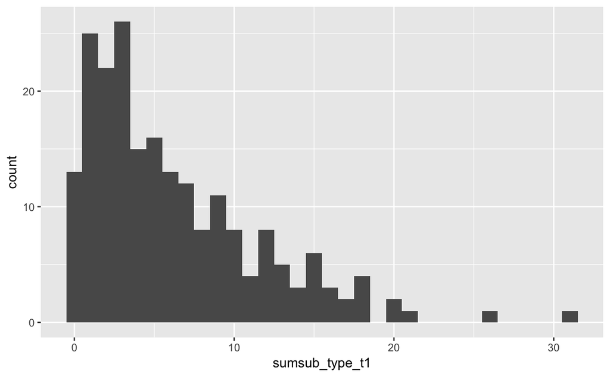

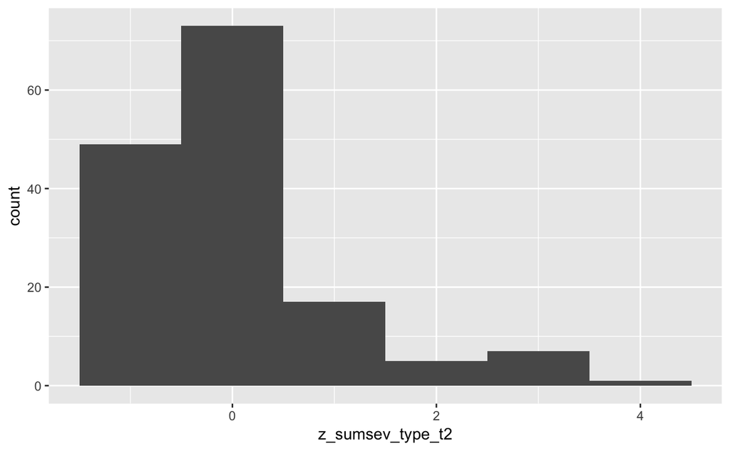

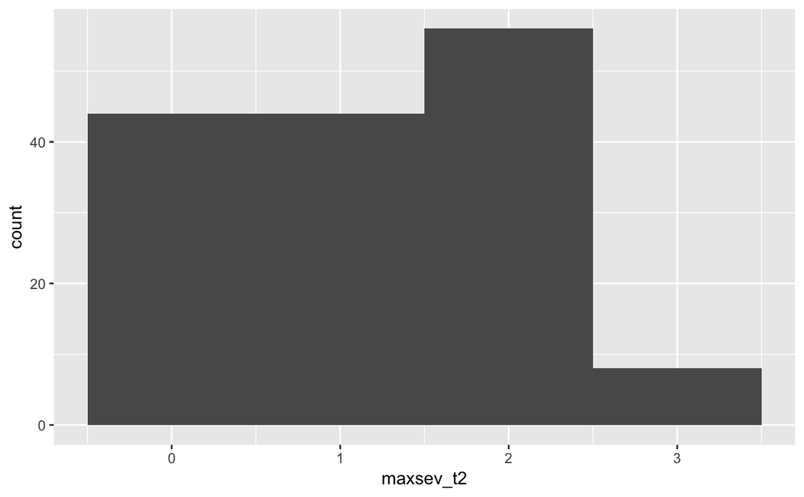

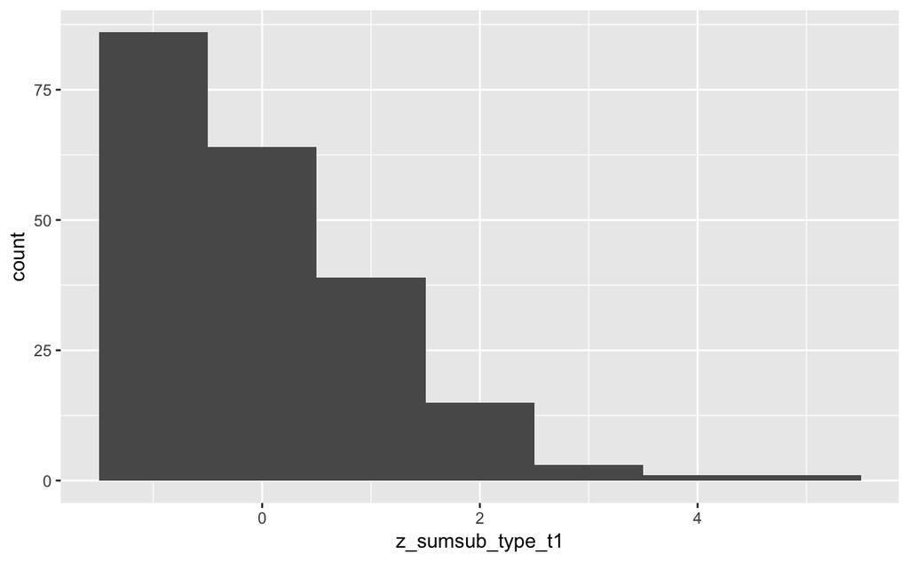

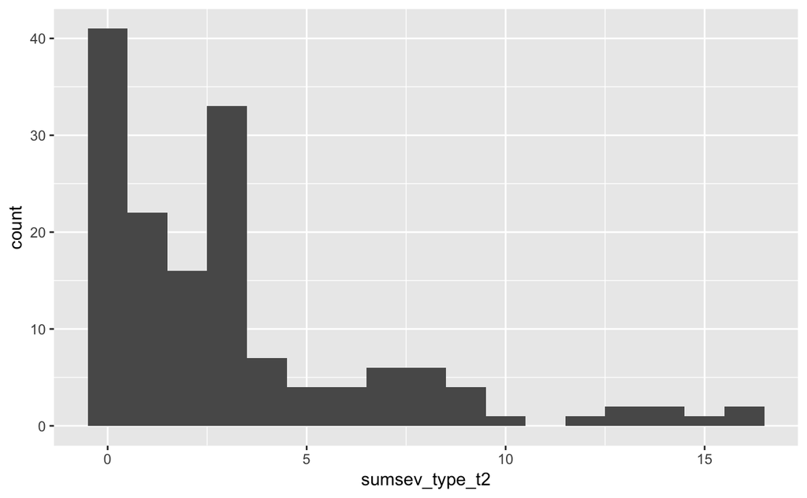

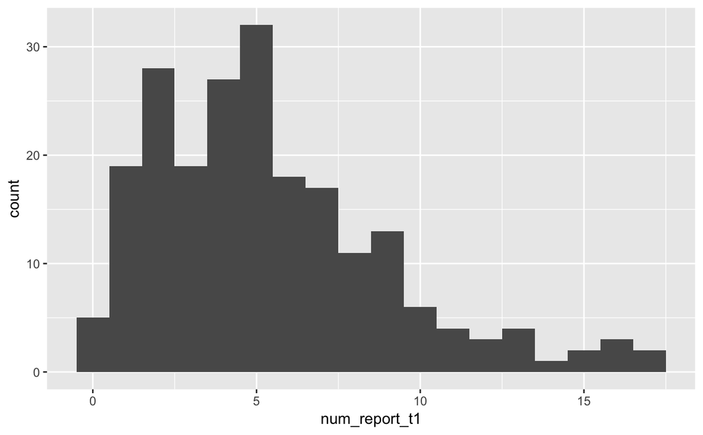

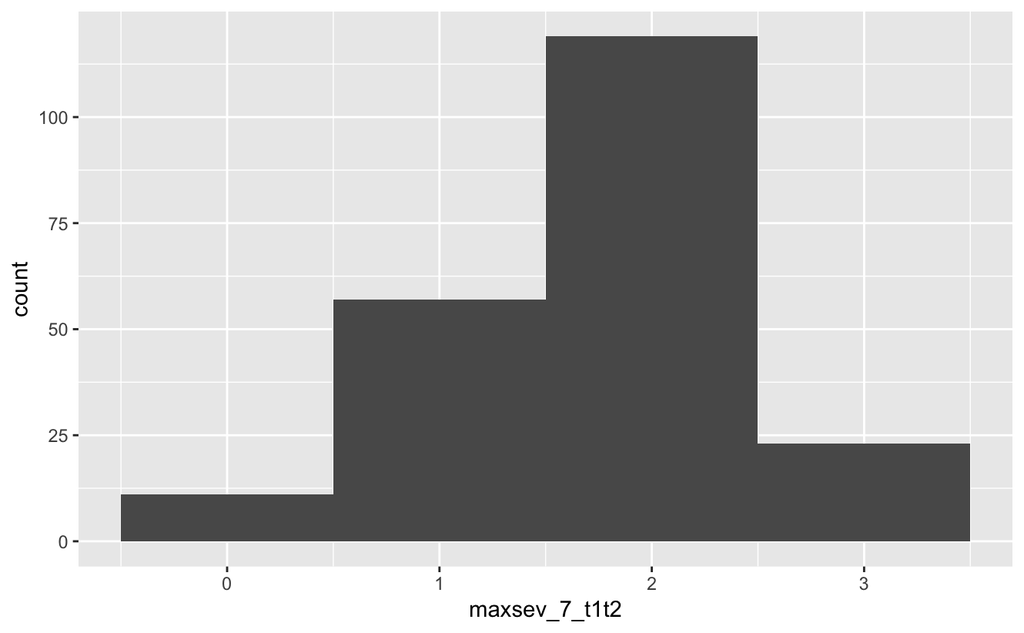

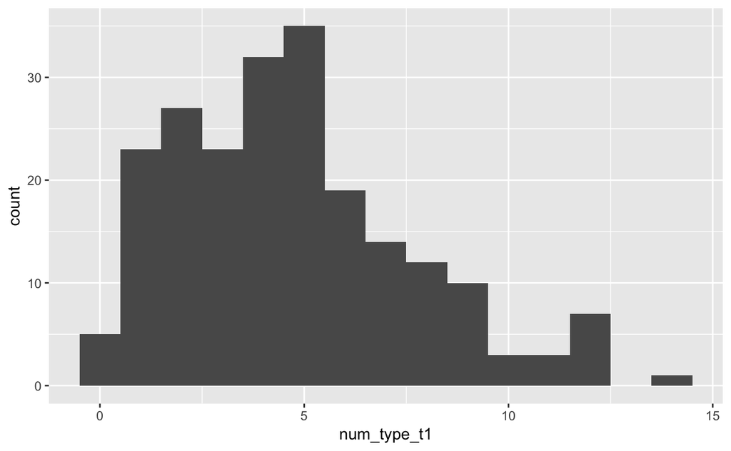

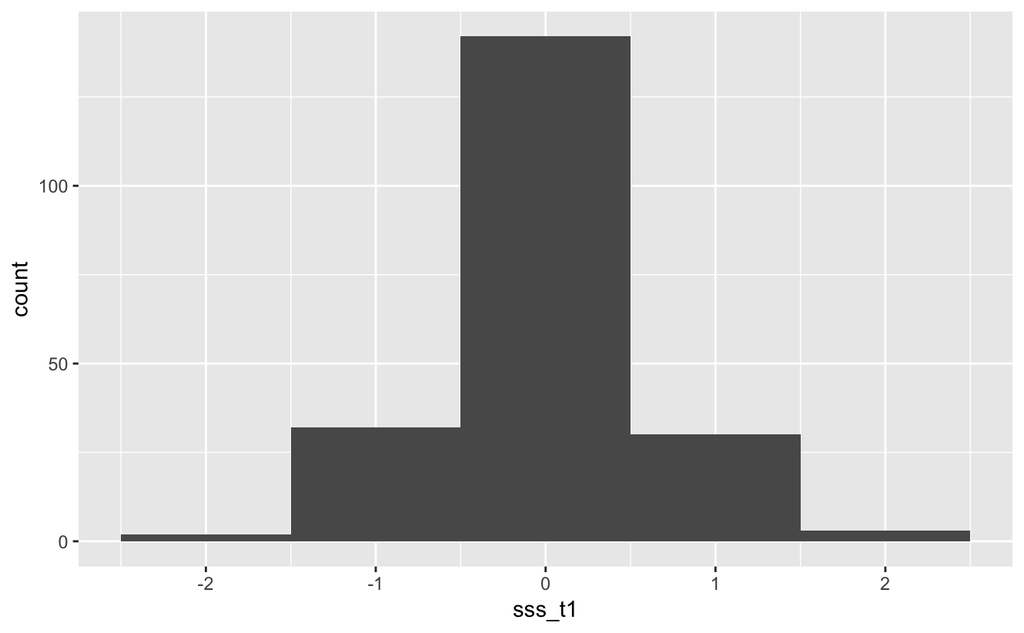

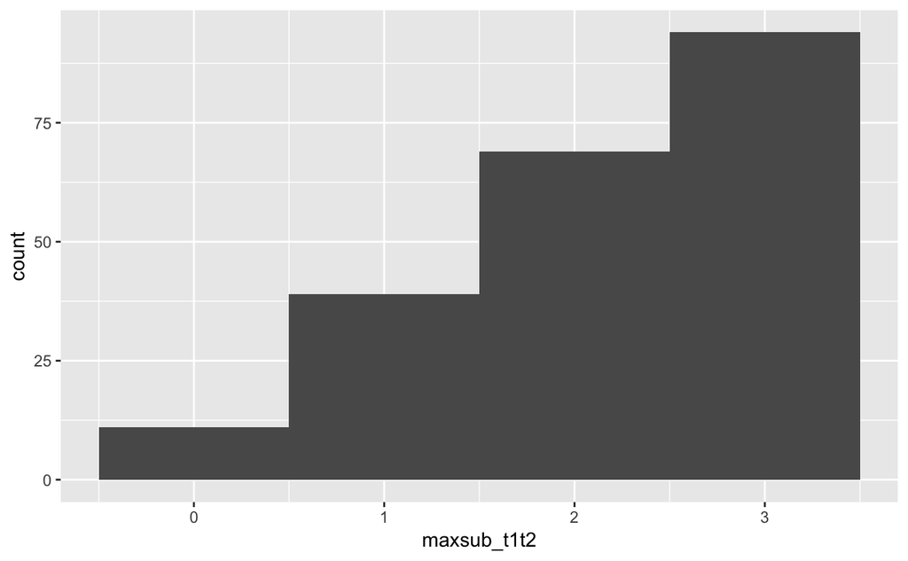

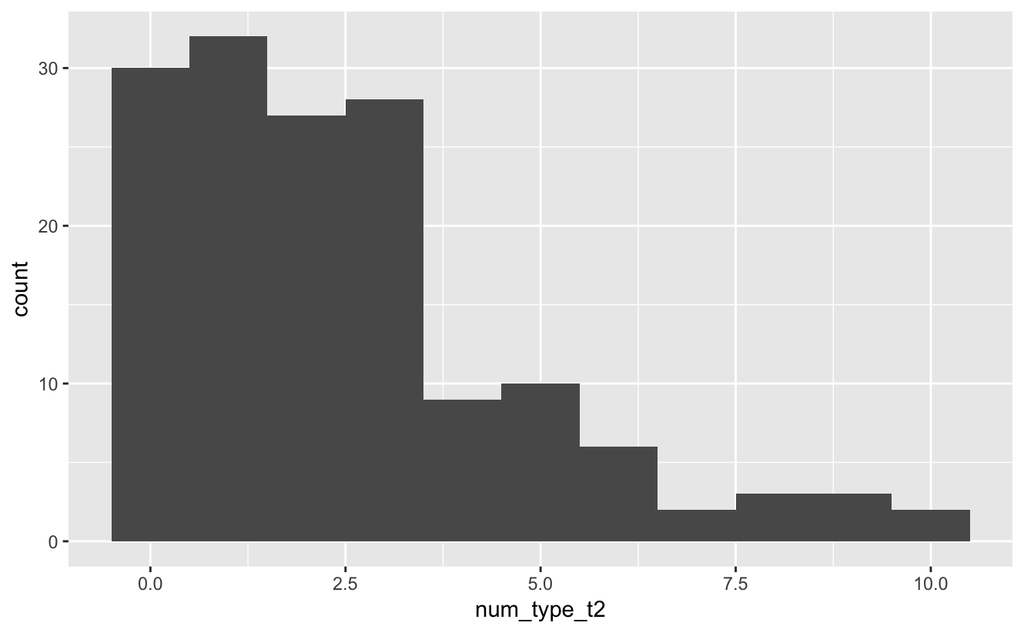

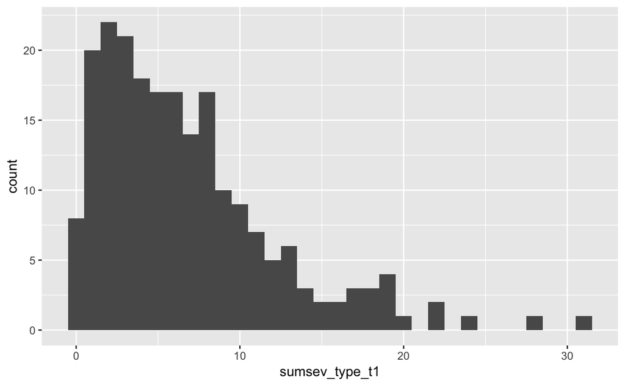

[27 more figures not shown]

```r
rating_vars <-
  els_all_ratings %>%
  select(-ELS_ID) %>%
  names()
histograms_ratings <- map(rating_vars, ~plot_histogram(.x))
histograms_ratings
```

```r
ratings_descriptives <-
  els_all_ratings %>%
  summarise_at(
    vars(-ELS_ID),
    funs(sum(!is.na(.)))
  ) %>%
  gather(variable, n) %>%
  left_join(
    els_all_ratings %>%
      summarise_at(
        vars(-ELS_ID),
        funs(mean),
        na.rm = TRUE
      ) %>%
      gather(variable, mean),
    by = "variable"
  ) %>%
  left_join(
    els_all_ratings %>%
      summarise_at(
        vars(-ELS_ID),
        funs(median),
        na.rm = TRUE
      ) %>%
      gather(variable, median),
    by = "variable"
  ) %>%
  left_join(
    els_all_ratings %>%
      summarise_at(
        vars(-ELS_ID),
        funs(sd),
        na.rm = TRUE
      ) %>%
      gather(variable, sd),
    by = "variable"
  ) %>%
  left_join(
    els_all_ratings %>%
      summarise_at(
        vars(-ELS_ID),
        funs(min),
        na.rm = TRUE
      ) %>%
      gather(variable, min),
    by = "variable"
  ) %>%
  left_join(
    els_all_ratings %>%
      summarise_at(
        vars(-ELS_ID),
        funs(max),
        na.rm = TRUE
      ) %>%
      gather(variable, max),
    by = "variable"
  )
knitr::kable(ratings_descriptives, digits = 2)
```

| variable | n | mean | median | sd | min | max |
| --- | --- | --- | --- | --- | --- | --- |
| sumsev_type_t1 | 214 | 6.97 | 6.00 | 5.51 | 0.00 | 31.50 |
| z_sumsev_type_t1 | 214 | 0.00 | -0.18 | 1.00 | -1.27 | 4.45 |
| maxsev_t1 | 214 | 2.09 | 2.00 | 0.84 | 0.00 | 4.00 |
| num_type_t1 | 214 | 4.71 | 4.00 | 2.90 | 0.00 | 14.00 |
| num_report_t1 | 214 | 5.37 | 5.00 | 3.61 | 0.00 | 17.00 |
| sumsub_type_t1 | 209 | 6.22 | 5.00 | 5.41 | 0.00 | 31.00 |
| z_sumsub_type_t1 | 209 | 0.00 | -0.23 | 1.00 | -1.15 | 4.58 |
| maxsub_t1 | 209 | 2.08 | 2.00 | 0.93 | 0.00 | 3.00 |
| sumsev_threat_t1 | 214 | 2.11 | 1.50 | 2.30 | 0.00 | 11.50 |
| sss_t1 | 209 | 0.00 | -0.06 | 0.58 | -2.21 | 2.19 |
| sumsev_type_t2 | 152 | 3.32 | 2.50 | 3.66 | 0.00 | 16.50 |
| z_sumsev_type_t2 | 152 | 0.00 | -0.22 | 1.00 | -0.91 | 3.61 |
| maxsev_t2 | 152 | 1.38 | 1.50 | 0.95 | 0.00 | 3.50 |
| num_type_t2 | 152 | 2.48 | 2.00 | 2.30 | 0.00 | 10.00 |
| num_report_t2 | 151 | 3.08 | 2.00 | 2.88 | 0.00 | 13.00 |
| sumsub_type_t2 | 152 | 2.95 | 2.00 | 3.73 | 0.00 | 24.00 |
| z_sumsub_type_t2 | 152 | 0.00 | -0.26 | 1.00 | -0.79 | 5.64 |
| maxsub_t2 | 152 | 1.30 | 1.00 | 1.00 | 0.00 | 3.00 |
| sumsev_threat_t2 | 152 | 1.02 | 0.00 | 1.72 | 0.00 | 8.00 |
| sss_t2 | 152 | 0.02 | -0.09 | 0.58 | -2.59 | 3.35 |
| sumsev_type_t1t2 | 214 | 8.51 | 7.00 | 6.35 | 0.00 | 31.50 |
| z_sumsev_type_t1t2 | 214 | 0.00 | -0.24 | 1.00 | -1.34 | 3.62 |
| maxsev_t1t2 | 214 | 2.21 | 2.00 | 0.79 | 0.00 | 4.00 |
| num_type_t1t2 | 214 | 5.76 | 5.00 | 3.41 | 0.00 | 17.00 |
| num_report_t1t2 | 214 | 7.69 | 7.00 | 5.28 | 0.00 | 34.00 |
| sumsub_type_t1t2 | 213 | 7.66 | 6.00 | 6.24 | 0.00 | 31.00 |
| z_sumsub_type_t1t2 | 213 | 0.00 | -0.27 | 1.00 | -1.23 | 3.74 |
| maxsub_t1t2 | 213 | 2.15 | 2.00 | 0.90 | 0.00 | 3.00 |
| sumsev_threat_t1t2 | 214 | 2.57 | 2.00 | 2.81 | 0.00 | 13.50 |
| sss_t1t2 | 213 | 0.00 | -0.06 | 0.57 | -2.07 | 1.85 |
| sumsev_type_6 | 125 | 3.72 | 2.50 | 3.42 | 0.50 | 17.00 |
| maxsev_6 | 125 | 1.94 | 2.00 | 0.96 | 0.50 | 4.00 |
| num_type_6 | 125 | 2.05 | 1.00 | 1.39 | 1.00 | 8.00 |
| sumsev_type_7 | 198 | 4.35 | 3.50 | 3.37 | 0.50 | 26.00 |
| maxsev_7 | 198 | 1.86 | 2.00 | 0.70 | 0.50 | 3.50 |
| num_type_7 | 198 | 3.14 | 3.00 | 1.91 | 1.00 | 11.00 |
| sumsev_type_7_t1t2 | 210 | 6.50 | 5.00 | 5.26 | 0.00 | 26.00 |
| maxsev_7_t1t2 | 210 | 1.97 | 2.00 | 0.73 | 0.00 | 3.50 |
| num_type_7_t1t2 | 210 | 4.75 | 4.00 | 3.30 | 0.00 | 17.00 |

# Frequencies of types

## T1

```r
els_t1_types <-
  els_t1_wf %>%
  select(
    ELS_ID,
    ends_with("panel_objective_decision_re")
  ) %>%
  mutate_at(
    vars(-ELS_ID),
    funs(as.integer(!is.na(.)))
  ) %>%
  rename_at(
    vars(-ELS_ID),
    funs(str_replace(., "_panel_objective_decision_re", "_t1"))
  )
```

```r
els_t1_frequency_table <-
  els_t1_types %>%
  gather(type, endorsed, -ELS_ID) %>%
  count(type, endorsed) %>%
  group_by(type) %>%
  mutate(
    percent = round(((n / sum(n)) * 100), 0)
  ) %>%
  filter(endorsed == 1) %>%
  arrange(desc(percent)) %>%
  select(-endorsed)
knitr::kable(els_t1_frequency_table)
```

| type | n | percent |
| --- | --- | --- |
| moved_t1 | 103 | 48 |
| wit_ill_t1 | 103 | 48 |
| parent_arg_t1 | 83 | 39 |
| death_t1 | 72 | 34 |
| bully_t1 | 71 | 33 |
| divorce_t1 | 68 | 32 |
| exp_ill_t1 | 64 | 30 |
| wit_acc_t1 | 56 | 26 |
| exp_acc_t1 | 48 | 22 |
| mental_ill_t1 | 40 | 19 |
| finance_t1 | 28 | 13 |
| sep_rfd_t1 | 28 | 13 |
| legal_prob_t1 | 25 | 12 |
| comm_inst_t1 | 24 | 11 |
| sep_wt_t1 | 24 | 11 |
| comm_phys_t1 | 22 | 10 |
| dom_viol_t1 | 19 | 9 |
| animal_t1 | 15 | 7 |
| other_t1 | 15 | 7 |
| suicide_t1 | 14 | 7 |
| neglect_t1 | 12 | 6 |
| comm_arg_t1 | 11 | 5 |
| disaster_t1 | 11 | 5 |
| emo_ab_t1 | 11 | 5 |
| phys_ab_t1 | 11 | 5 |
| mug_rob_t1 | 7 | 3 |
| war_terr_t1 | 6 | 3 |
| nothing_reported_t1 | 5 | 2 |
| sex_ab_t1 | 4 | 2 |
| thrt_domvio_t1 | 5 | 2 |
| thrt_phys_ab_t1 | 4 | 2 |
| kidnap_t1 | 3 | 1 |
| wit_sexab_t1 | 1 | 0 |

## T2

```r
els_t2_types <-
  els_t2_wf %>%
  select(
    ELS_ID,
    ends_with("panel_objective_decision_re")
  ) %>%
  mutate_at(
    vars(-ELS_ID),
    funs(as.integer(!is.na(.)))
  ) %>%
  rename_at(
    vars(-ELS_ID),
    funs(str_replace(., "_panel_objective_decision_re", "_t2"))
  )
```

```r
els_t2_frequency_table <-
  els_t2_types %>%
  gather(type, endorsed, -ELS_ID) %>%
  count(type, endorsed) %>%
  group_by(type) %>%
  mutate(
    percent = round(((n / sum(n)) * 100), 0)
  ) %>%
  filter(endorsed == 1) %>%
  arrange(desc(percent)) %>%
  select(-endorsed)
knitr::kable(els_t2_frequency_table)
```

| type | n | percent |
| --- | --- | --- |
| wit_ill_t2 | 55 | 35 |
| moved_t2 | 42 | 27 |
| death_t2 | 35 | 23 |
| parent_arg_t2 | 36 | 23 |
| mental_ill_t2 | 30 | 19 |
| nothing_reported_t2 | 29 | 19 |
| wit_acc_t2 | 26 | 17 |
| bully_t2 | 25 | 16 |
| suicide_t2 | 19 | 12 |
| comm_phys_t2 | 17 | 11 |
| exp_ill_t2 | 16 | 10 |
| finance_t2 | 16 | 10 |
| legal_prob_t2 | 15 | 10 |
| other_t2 | 14 | 9 |
| comm_arg_t2 | 10 | 6 |
| emo_ab_t2 | 9 | 6 |
| exp_acc_t2 | 10 | 6 |
| divorce_t2 | 8 | 5 |
| sep_rfd_t2 | 7 | 5 |
| comm_inst_t2 | 6 | 4 |
| sep_wt_t2 | 6 | 4 |
| animal_t2 | 4 | 3 |
| disaster_t2 | 4 | 3 |
| mug_rob_t2 | 5 | 3 |
| dom_viol_t2 | 3 | 2 |
| war_terr_t2 | 3 | 2 |
| neglect_t2 | 1 | 1 |
| thrt_domvio_t2 | 1 | 1 |
| thrt_phys_ab_t2 | 1 | 1 |

## Join types with ratings file

```r
els_all_ratings <-
  els_all_ratings %>%
  left_join(els_t1_types, by = "ELS_ID") %>%
  left_join(els_t2_types, by = "ELS_ID") %>%
  distinct(ELS_ID, sumsev_type_t1, .keep_all = TRUE) %>%
  left_join(
    read_csv(lca_class_t1_file) %>%
      mutate(
        class = case_when(
          class == 1 ~ "direct_victim",
          class == 2 ~ "family_instab",
          class == 3 ~ "typical_low"
        )
      ),
    by = "ELS_ID"
  )
```

```r
glimpse(els_all_ratings
        )
```

```
Observations: 214
Variables: 103
$ ELS_ID              <dbl> 1, 2, 3, 4, 5, 6, 9, 10, 11, 12, 13, 14, 15, 16, 17, 18, 1…
$ sumsev_type_t1      <dbl> 2.0, 12.0, 1.0, 3.5, 11.5, 14.5, 10.5, 13.0, 10.5, 5.0, 3.…
$ z_sumsev_type_t1    <dbl> -0.903006977, 0.913191266, -1.084626801, -0.630577241, 0.8…
$ maxsev_t1           <dbl> 2.0, 2.5, 1.0, 1.0, 2.5, 3.5, 2.0, 2.5, 2.5, 2.5, 2.0, 2.5…
$ num_type_t1         <dbl> 1, 9, 1, 4, 9, 7, 9, 9, 8, 4, 3, 7, 11, 4, 4, 4, 6, 4, 5, …
$ num_report_t1       <dbl> 1, 10, 2, 4, 9, 7, 9, 9, 9, 4, 3, 9, 14, 4, 4, 4, 7, 4, 5,…
$ sumsub_type_t1      <dbl> 0, 18, 1, 7, 14, 13, 18, 13, 12, 5, 4, 9, 11, 3, 3, 9, 7, …
$ z_sumsub_type_t1    <dbl> -1.15075094, 2.17678561, -0.96588780, 0.14329105, 1.437333…
$ maxsub_t1           <dbl> 0, 3, 1, 3, 2, 3, 3, 3, 3, 2, 3, 2, 3, 1, 1, 3, 3, 2, 3, 1…
$ sumsev_threat_t1    <dbl> 0.0, 7.0, 0.0, 1.5, 4.5, 4.0, 2.5, 5.5, 4.5, 0.0, 0.0, 4.0…
$ sss_t1              <dbl> -0.39413374, 1.45414186, -0.06134450, 0.67801911, 0.788652…
$ sumsev_type_t2      <dbl> 0.0, 2.0, 0.5, NA, 7.0, 7.0, 8.0, 15.5, NA, 0.0, 6.0, 6.5,…
$ z_sumsev_type_t2    <dbl> -0.90796629, -0.36084686, -0.77118643, NA, 1.00695171, 1.0…
```

[output cut: 90 more lines]